# Seguimiento PF 2017-04-20

Cristian Gómez Alvarez

17 de abril de 2017

## Correlación y Regresión

En el siguiente ejercicio se estudiará la correlación entre el resultado de hemoglobina glicosilada (HbA1c) y la creatinina en personas diabéticas en tres periodos de tiempo independientes (sin influencia de la hemoglobina glicosilada que tiene un periodo de 3 meses de medición). Un valor controlado de HbA1c es inferior a 7% para diabéticos y de creatinina es entre 0.7 y 1.3 mg/dL para hombres y 0.6 - 1.1 mg/dL para mujeres.

Si la correlación es muy baja entre ambas variables se probará también con trigliceridos cuyos valores referencia son <150 controlado, >200 alto.

Preparar librerías requeridas

```
## data.table + dplyr code now lives in dtplyr.
## Please library(dtplyr)!
```

Cargar los datos(dataset completo)

```r
cohorte<-fread("T_Cohorte.csv", sep="\t", na.strings="NA")
```

[output not shown]

Resumen del dataset

```r
summary(cohorte)
```

```
##    idpersona         fecha                edad        indice_charlson
##  Min.   :     1   Length:3545364     Min.   : -1.00   Mode:logical
##  1st Qu.: 40548   Class :character   1st Qu.: 39.00   NA's:3545364
##  Median : 81290   Mode  :character   Median : 56.00
##  Mean   : 79573                      Mean   : 51.01
##  3rd Qu.:118815                      3rd Qu.: 67.00
##  Max.   :156680                      Max.   :111.00
##
##  dias_patologia anios_patologia meses_patologia  presion_sistolica
##  Min.   :   0   Min.   :0.000   Min.   : 0.000   Length:3545364
##  1st Qu.: 913   1st Qu.:2.000   1st Qu.: 1.000   Class :character
##  Median :1277   Median :3.000   Median : 4.000   Mode  :character
##  Mean   :1178   Mean   :2.774   Mean   : 4.571
##  3rd Qu.:1550   3rd Qu.:4.000   3rd Qu.: 7.000
##  Max.   :1826   Max.   :5.000   Max.   :10.000
##
##  presion_diastolica     pam             framingham
##  Length:3545364     Length:3545364     Length:3545364
##  Class :character   Class :character   Class :character
##  Mode  :character   Mode  :character   Mode  :character
##
##
##
##
##      tfg                imc                 peso            talla
##  Length:3545364     Length:3545364     Min.   : 50      Min.   : 90
##  Class :character   Class :character   1st Qu.: 67      1st Qu.:115
##  Mode  :character   Mode  :character   Median : 85      Median :140
##                                        Mean   : 85      Mean   :140
##                                        3rd Qu.:103      3rd Qu.:165
##                                        Max.   :120      Max.   :190
##                                        NA's   :620139   NA's   :620139
##  perimetro_abdominal frecuencia_cardiaca saturacion_oxigeno
##  Min.   : 60         Min.   : 90         Min.   :10
##  1st Qu.: 75         1st Qu.:105         1st Qu.:30
##  Median : 90         Median :120         Median :50
##  Mean   : 90         Mean   :120         Mean   :50
##  3rd Qu.:105         3rd Qu.:135         3rd Qu.:70
##  Max.   :120         Max.   :150         Max.   :90
##  NA's   :620139      NA's   :620139      NA's   :620139
```

[output cut: 121 more lines]

```
##  Mode:logical   Mode:logical   Mode:logical   Mode:logical
##  NA's:3545364   NA's:3545364   NA's:3545364   NA's:3545364
##
##
##
##
##
##  fecha_pulmon
##  Mode:logical
##  NA's:3545364
##
##
##
##
##
```

Los campos de nuestro interés son `idpersona`, `fecha`, `creatinina`, `hemoglobina`y `trigliceridos` por lo que se descartarán los demás campos y se crearán 3 datasets de los datos para meses donde la hemoglobina no tenga influencia (examen de 3 meses de ventana).

```r
cohorte<-cohorte%>%select(idpersona, fecha, creatinina, hemoglobina, trigliceridos)

##Datasets
cohorte_ene<-cohorte%>%filter(fecha=="2015-01-31")
cohorte_may<-cohorte%>%filter(fecha=="2015-05-31")
cohorte_ago<-cohorte%>%filter(fecha=="2015-08-31")
```

## Correlación Enero

Gráfico de creatinina vs hemoglobina.

[figure not shown]

Analicemos ahora qué pasa con los triglicéridos en función de la hemoglobina, qué indica ésta

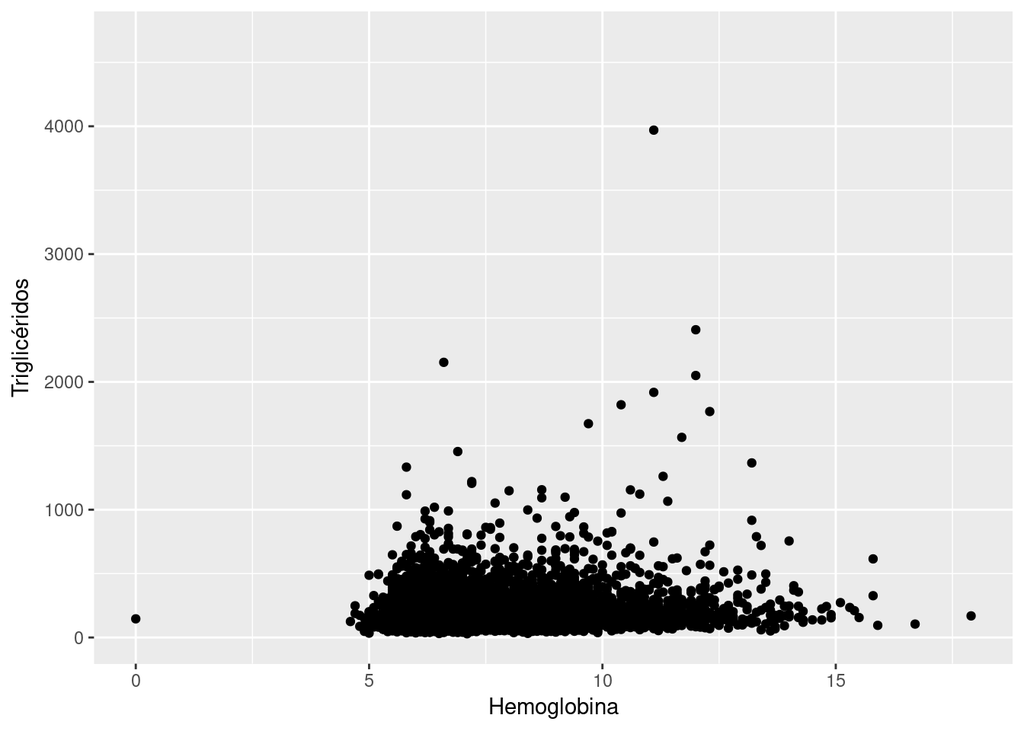

Búsqueda de outliers. Personas que tienen una creatinina >=2.5 y hemoglobina >=13

```r
cohorte_ene%>%
  filter(creatinina>=2.5, hemoglobina>=13)
```

```
##   idpersona      fecha creatinina hemoglobina trigliceridos
## 1     86910 2015-01-31       2.71        13.6           307
## 2     91577 2015-01-31       2.67        13.0           271
## 3    146749 2015-01-31       2.68        14.2           245
```

### Indice de correlación

```r
cohorte_ene %>%
  summarize(N = n(), r = cor(creatinina, hemoglobina, use = "pairwise.complete.obs"))
```

```
##        N           r
## 1 148527 -0.05988705
```

```r
#0.16
cohorte_may %>%
  summarize(N = n(), r = cor(hemoglobina, trigliceridos, use = "pairwise.complete.obs"))
```

```
##        N         r
## 1 152634 0.1499863
```

```r
cohorte %>%
  summarize(N = n(), r = cor(hemoglobina, trigliceridos, use = "pairwise.complete.obs"))
```

```
##         N         r
## 1 3545364 0.1616618
```

El índice de correlación es muy bajo por lo que no podemos determinar una relación fuerte entre ambas variables. Veamos ahora cómo se comporta un modelo linear con ésta relación.

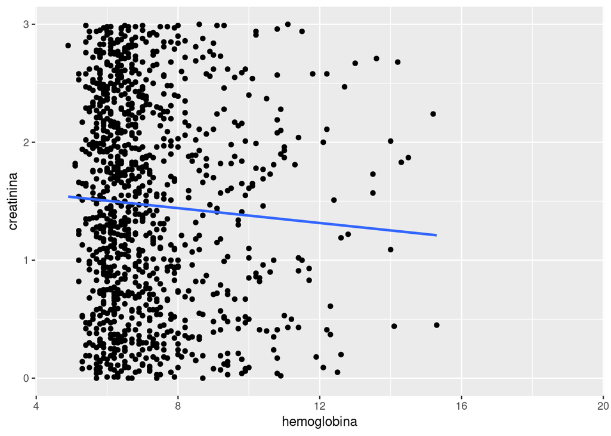

```r
ggplot(data = cohorte_ene, aes(x = hemoglobina, y = creatinina)) +
  geom_point() +
  geom_smooth(method = lm, se = FALSE)
```

Según la gráfica la relación es negativa, ahora veamos sus parámetros e interpretaciones

```r
mod<-lm(creatinina~hemoglobina, data = cohorte_ene)
summary(mod)
```

```
##
## Call:
## lm(formula = creatinina ~ hemoglobina, data = cohorte_ene)
##
## Residuals:
##      Min       1Q   Median       3Q      Max
## -1.51403 -0.77143 -0.00513  0.75048  1.65609
##
## Coefficients:
##             Estimate Std. Error t value Pr(>|t|)
## (Intercept)  1.69360    0.11705   14.47   <2e-16 ***
## hemoglobina -0.03150    0.01591   -1.98    0.048 *
## ---
## Signif. codes:  0 '***' 0.001 '**' 0.01 '*' 0.05 '.' 0.1 ' ' 1
##
## Residual standard error: 0.8714 on 1089 degrees of freedom
##   (147436 observations deleted due to missingness)
## Multiple R-squared:  0.003586,   Adjusted R-squared:  0.002671
## F-statistic:  3.92 on 1 and 1089 DF,  p-value: 0.04797
```

El intercepto es 1.6936 y la pendiente -0.03150 lo que significa que un cambio de 1% en el valor de la hemoglobina representa un cambio de -0.03150 en la creatinina.

El error de la raíz cuadrada de la media (RSME) indica que un valor ajustado para el modelo va a variar en 0.8714 unidades (en el caso de la creatinina, mg/dL) respecto a un valor real.

### Predicciones usando el modelo linear

```r
predict(mod, newdata=list(hemoglobina=8))
```

```
##        1
## 1.441574
```

## Coeficiente de determinación (R2)

```r
cohorte_acond<-augment(mod)

#Calcular R2
cohorte_acond %>%
  summarize(var_y = var(creatinina), var_e = var(residuals(mod))) %>%
  mutate(R_squared = 1-(var_e/var_y))
```

```
##       var_y     var_e   R_squared
## 1 0.7614023 0.7586716 0.003586459
```

El 0.35% de la variación de creatinina puede ser explicado por el valor de la hemoglobina

## Apalancamiento e influencia

Apalancamiento: define la distancia del valor de la media de la variable explicatoria. Entre más valor de apalancamiento más distante de la media, sin embargo ésto no significa que la observación tenga mayor influencia.

```r
mod %>%
  augment() %>%
  arrange(desc(.hat)) %>%
  head(6)
```

```
##   .rownames creatinina hemoglobina  .fitted   .se.fit     .resid
## 1     39919       0.45        15.3 1.211597 0.1320827 -0.7615965
## 2     91399       2.24        15.2 1.214747 0.1305239  1.0252531
## 3     10652       1.87        14.5 1.236799 0.1196363  0.6332005
## 4    111197       1.83        14.3 1.243100 0.1165343  0.5868998
## 5    138924       2.68        14.2 1.246251 0.1149850  1.4337494
## 6     78883       0.44        14.1 1.249401 0.1134368 -0.8094010
##         .hat    .sigma     .cooksd .std.resid
## 1 0.02297414 0.8715048 0.009191675 -0.8841902
## 2 0.02243508 0.8712508 0.016248609  1.1899592
## 3 0.01884837 0.8716023 0.005168942  0.7335791
## 4 0.01788362 0.8716329 0.004205086  0.6796045
## 5 0.01741124 0.8707143 0.024409011  1.6598205
## 6 0.01694553 0.8714664 0.007563889 -0.9368039
```

Influencia: la influencia depende del valor de apalancamiento de la observación así como de la magnitud de su residuo. Los puntos influenciadores tienen tendencia a tener apalancamiento alto y desviarse de la relación general de las dos variables.

```r
mod %>%
  augment() %>%
  arrange(desc(.cooksd)) %>%
  head(6)
```

```
##   .rownames creatinina hemoglobina  .fitted    .se.fit   .resid
## 1    138924       2.68        14.2 1.246251 0.11498497 1.433749
## 2     80073       2.71        13.6 1.265153 0.10571495 1.444847
## 3     91399       2.24        15.2 1.214747 0.13052390 1.025253
## 4     84659       2.67        13.0 1.284055 0.09649905 1.385945
## 5     38532       2.94        11.5 1.331311 0.07382880 1.608689
## 6    112465       3.00        11.1 1.343912 0.06792221 1.656088
##          .hat    .sigma    .cooksd .std.resid
## 1 0.017411241 0.8707143 0.02440901   1.659821
## 2 0.014717038 0.8707002 0.02083818   1.670380
## 3 0.022435081 0.8712508 0.01624861   1.189959
## 4 0.012262912 0.8707921 0.01589719   1.600291
## 5 0.007177930 0.8704427 0.01240847   1.852722
## 6 0.006075349 0.8703620 0.01110577   1.906253
```